# Deliverable Part 1

In my data set there is 26 variables and nearly 2 million obersvations. Some of the categorical variables that are going to be the most useful will be Crime.Code.Description, Crime.Code, and Area Name.

# SYNOPSIS

## In my Victim table, I have the variables;

Categorical  
***  
Descent (Victims ethnicity)  
Sex (Gender)

Continuous *** Report number (Number that represents the reported case)  
Age (Age of victim)

## In my CrimeDetails table I Have the Variables;

Categorical  
***  
Report_Number (Number that identifies the reported crime),  
Area_Name (Name of LA area the crime took place in),  
Crime_Code (Code of the crime committed),  
Crime_Description (Description of the crime commited),  
Premise_Code (Code for what type of premise the crime took place on),  
Premise_Description (which describe the premices where the crime took place),  
Weapon_Code (Code for what weapon was used),  
Weapon_Description (Brief description of the weapon if used),  
Status_Code, (Code showing the current status of the case EX: closed, open),  
Status_Description (which describes the status of the case),  
Crime_Code2-4 (for if more than one crime was committed),  
Address(for where crime was committed),  
Cross_Street (for the cross street of the crime),

Continuous  
***  
Report_Number, Date_reported,  
Date_Occurred, Time_Occured

# Data Initialization

This is where I install the tidyverse and load in appropriate libraries for data wrangling

```r
#install.packages("tidyverse")
crime <- read.csv("./crime-data-from-2010-to-present.csv", header=TRUE)
library("ggplot2")
library("tidyverse")
library("readr")
library("dplyr")
library("tidyr")
library("plyr")
## Clean up data, make victim, and crime tables, fix 0 or blanks with NA

Victim<-tibble(Report_Number = crime$DR.Number, Age = crime$Victim.Age, Descent = crime$Victim.Descent, Sex = crime$Victim.Sex)

CrimeDetails<-tibble(Report_Number = crime$DR.Number, Date_Reported = crime$Date.Reported, Date_Occurred = crime$Date.Occurred, Time_Occurred = crime$Time.Occurred, Area_Name = crime$Area.Name,Crime_Description = crime$Crime.Code.Description, Premise_Description = crime$Premise.Description, Weapon_Description = crime$Weapon.Description, Status_Description = crime$Status.Description, Address = crime$Address, Cross_Street = crime$Cross.Street)

Victim$Age[Victim$Age == "0"]<- NA
Victim$Sex[Victim$Sex == " "]<- NA
Victim$Descent[Victim$Descent == " "]<- NA
CrimeDetails$Weapon_Description[CrimeDetails$Weapon_Description == " "]<- NA
CrimeDetails$Weapon_Description<- lapply(CrimeDetails$Weapon_Description, gsub, pattern = " ", replacement = NA)
Victim<-na.omit(Victim)

CrimeDetails
```

```
## # A tibble: 1,993,259 x 11
##    Report_Number Date_Reported Date_Occurred Time_Occurred Area_Name
##            <int> <fct>         <fct>                 <int> <fct>
##  1     102005556 2010-01-25T0~ 2010-01-22T0~          2300 Olympic
##  2     101822289 2010-11-11T0~ 2010-11-10T0~          1800 Southeast
##  3     101105609 2010-01-28T0~ 2010-01-27T0~          2230 Northeast
##  4     101620051 2010-11-11T0~ 2010-11-07T0~          1600 Foothill
##  5     101910498 2010-04-07T0~ 2010-04-07T0~          1600 Mission
##  6     101927640 2010-12-31T0~ 2010-12-30T0~          2100 Mission
##  7     101323794 2010-10-26T0~ 2010-10-26T0~          1315 Newton
##  8     101009426 2010-04-20T0~ 2010-04-20T0~          1230 West Val~
##  9     101621795 2010-12-21T0~ 2010-12-21T0~          1200 Foothill
## 10     101105990 2010-02-04T0~ 2010-02-03T0~          1800 Northeast
## # ... with 1,993,249 more rows, and 6 more variables:
## #   Crime_Description <fct>, Premise_Description <fct>,
## #   Weapon_Description <list>, Status_Description <fct>, Address <fct>,
## #   Cross_Street <fct>
```

```r
Victim
```

```
## # A tibble: 1,647,041 x 4
##    Report_Number   Age Descent Sex
##            <int> <int> <fct>   <fct>
##  1     101111639    41 W       F
##  2     101306897    10 H       F
##  3     101405545    43 H       M
##  4     101420432    22 W       F
##  5     101500638    19 H       M
##  6     101708201    22 H       F
##  7     131318519    62 W       M
##  8     101012262    24 O       M
##  9     101519896    31 O       M
## 10     101618290    21 W       F
## # ... with 1,647,031 more rows
```

```r
#crimeOverTime<-tibble(Date = CrimeDetails$Date_Reported[CrimeDetails$Date_Reported == "2018"], Description = CrimeDetails$Crime_Description, Victim_age = Victim$Age, victim_sex = Victim$Sex)
```

This is where I run my posix to fix the dates up, for some reason it works on Date Reported but it wont work on date Occurred. Another problem was a good chunk of data having wrong input for the date but it wasn’t enough to skew results, so I just left them omiited.

```r
#Fixing the date and times for my code

CrimeDetails$Date_Reported <- lapply(CrimeDetails$Date_Reported, gsub, pattern="T", replacement=" ")

CrimeDetails$Date_Occurred <- lapply(CrimeDetails$Date_Occurred, gsub, pattern="T", replacement="  ")

CrimeDetails$Date_Reported<-as.POSIXlt(parse_datetime(as.character(CrimeDetails$Date_Reported), format = "%Y-%m-%d %H:%M:%S"))
#typeof(CrimeDetails$Date_Reported)
```

## The 3 most common crimes and areas were

```r
mostCommon<-names(sort(summary(as.factor(CrimeDetails$Crime_Description)), decreasing=T)[1:3])
mostCommon
```

```
## [1] "BATTERY - SIMPLE ASSAULT" "BURGLARY FROM VEHICLE"
## [3] "VEHICLE - STOLEN"
```

```r
mostCommonArea<-names(sort(summary(as.factor(CrimeDetails$Area_Name)), decreasing=T)[1:3])
mostCommonArea
```

```
## [1] "77th Street" "Southwest"   "N Hollywood"
```

## Manipulating data

In this section I use the count function to get the total numbers of Stolen Vehicles, Battery, and burglary from vehicle. After that I created a function called getTheCountOf which takes 2 variables, crimeName and areaName and returns the number of reported incidents of crime in that area. After that I put them in a dataframe and gather them so I could properly graph them.

```r
countOfStolenVehicle<-count(CrimeDetails$Crime_Description[CrimeDetails$Crime_Description == "VEHICLE - STOLEN"])
countOfBattery<-count(CrimeDetails$Crime_Description[CrimeDetails$Crime_Description == "BATTERY - SIMPLE ASSAULT"])
countOfBurglary<-count(CrimeDetails$Crime_Description[CrimeDetails$Crime_Description == "BURGLARY FROM VEHICLE"])

getTheCount<-function(crimeName,areaName){
  CrimeCount<-count(CrimeDetails$Crime_Description[CrimeDetails$Crime_Description == crimeName & CrimeDetails$Area_Name == areaName])
  return(CrimeCount)
}

#Here is where i get the counts for the 3 top crimes on 77th Street
SeventhVehicle<-getTheCount("VEHICLE - STOLEN","77th Street")
SeventhBattery<-getTheCount("BATTERY - SIMPLE ASSAULT", "77th Street")
SeventhBurglary<-getTheCount("BURGLARY FROM VEHICLE","77th Street")

#Here is where I get the count of the top 3 crimes in the Southwest
SouthwestVehicle<-getTheCount("VEHICLE - STOLEN","Southwest")
SouthwestBattery<-getTheCount("BATTERY - SIMPLE ASSAULT","Southwest")
SouthwestBurglary<-getTheCount("BURGLARY FROM VEHICLE","Southwest")

#Here is where I get the count of the top 3 crimes in N Hollywood
NHollywoodVehicle<-getTheCount("VEHICLE - STOLEN","N Hollywood")
NHollywoodBattery<-getTheCount("BATTERY - SIMPLE ASSAULT", "N Hollywood")
NHollywoodBurglary<-getTheCount("BURGLARY FROM VEHICLE", "N Hollywood")

#Here is where I get the count of the top 3 crimes in Pacific
#PacificVehicle<-getTheCount("VEHICLE - STOLEN","Pacific")
#PacificBattery<-getTheCount("BATTERY - SIMPLE ASSAULT", "Pacific")
#PacificBurglary<-getTheCount("BURGLARY FROM VEHICLE","Pacific")

#Here is where I get the count of top 3 crimes in Southeast
#SoutheastVehicle<-getTheCount("VEHICLE - STOLEN","Southeast")
#SoutheastBattery<-getTheCount("BATTERY - SIMPLE ASSAULT","Southeast")
#SoutheastBurglary<-getTheCount("BURGLARY FROM VEHICLE","Southeast")

Battery<-c(SeventhBattery$freq,SouthwestBattery$freq,NHollywoodBattery$freq)
Burglary<-c(SeventhBurglary$freq,SouthwestBurglary$freq,NHollywoodBurglary$freq)
VehicleTheft<-c(SeventhVehicle$freq,SouthwestVehicle$freq,NHollywoodVehicle$freq)


topCrimesAndAreas<-tibble(Area = mostCommonArea, CrimeType = mostCommon,Battery = Battery, Burglary = Burglary, VehicleTheft = VehicleTheft)

topCrimesAndAreas<-gather(topCrimesAndAreas, "CrimeType", "Count", 3:5)
```

# Visualizing some of my data

Here I use the data I tidied up and graphed the 3 top crimes in the 3 cities with the most reported Crime.

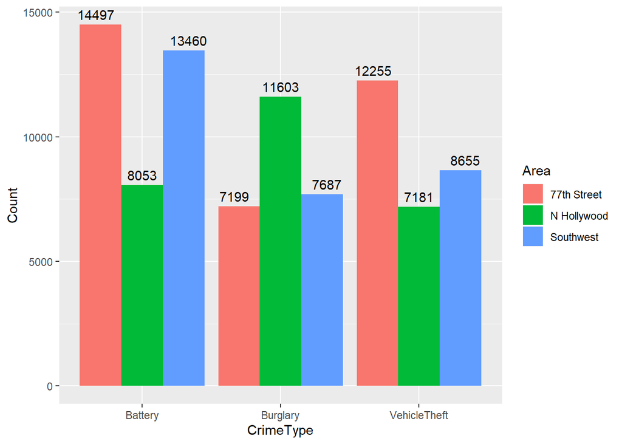

```r
#Plotting number of crimes vs Area
ggplot(topCrimesAndAreas, aes(fill = Area,x = CrimeType, y =Count)) + geom_bar(position = "dodge",stat = "identity")+geom_text(aes(label=Count), position=position_dodge(width=1.0), vjust=-.5)
```

Here you can see that 77th Street led the charts in Battery and Vehicle theft. That was the most active area of reported crimes in my dataset.